# Week 0

Santiago Barreda

9/28/2020

## Average Height

```
## SHA-1 hash of file is aaef6991ddef06264dbe7a8d68c562e8cedd374f
```

The average height of adult women in the USA is 63.8 inches. We can represent this with a single point along the x axis.

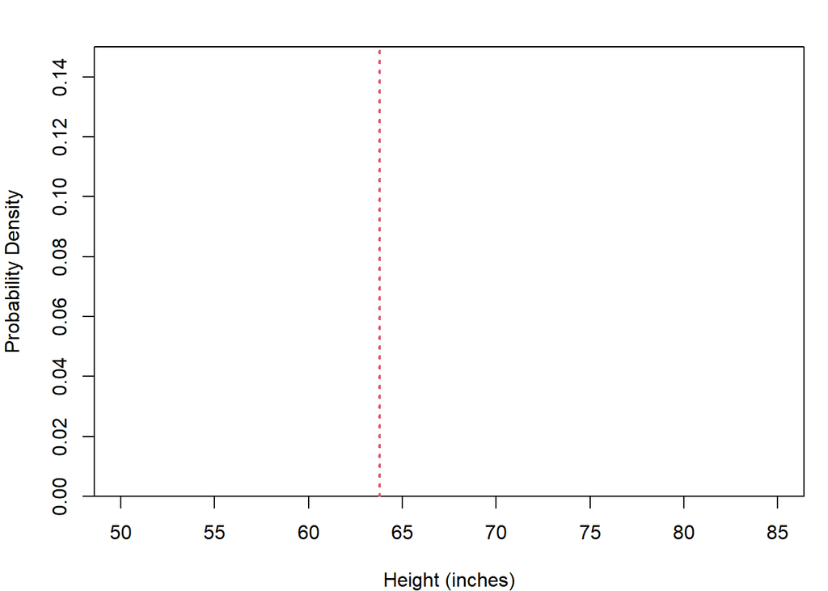

```r
plot (0, xlim = c(50,85), ylim = c(0,.15), xlab = 'Height (inches)', yaxs='i', ylab='Probability Density')
abline (v = 63.8, lwd = 2, col = 2, lty=3)
```

Basically, the population looks something like below, although that distribution is bad for several different reasons.

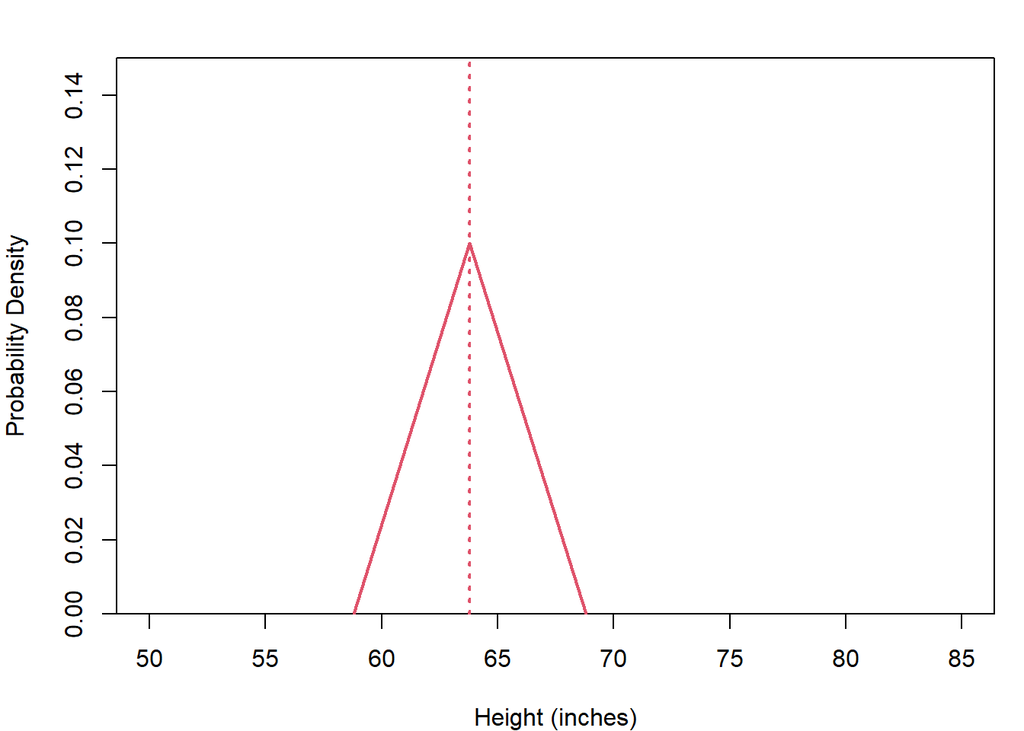

```r
plot (0, xlim = c(50,85), ylim = c(0,.15), xlab = 'Height (inches)', yaxs='i', ylab='Probability Density')
abline (v = 63.8, lwd = 2, col = 2, lty=3)
segments (c(63.8-5,63.8+5),c(0,0),c(63.8,63.8),c(0.1,0.1), lwd=2, col = 2)
```

The distribution of female heights is normally distributed. This means if you take a random sample of a large number of women and arrange observations into bins, they will tend to look like this:

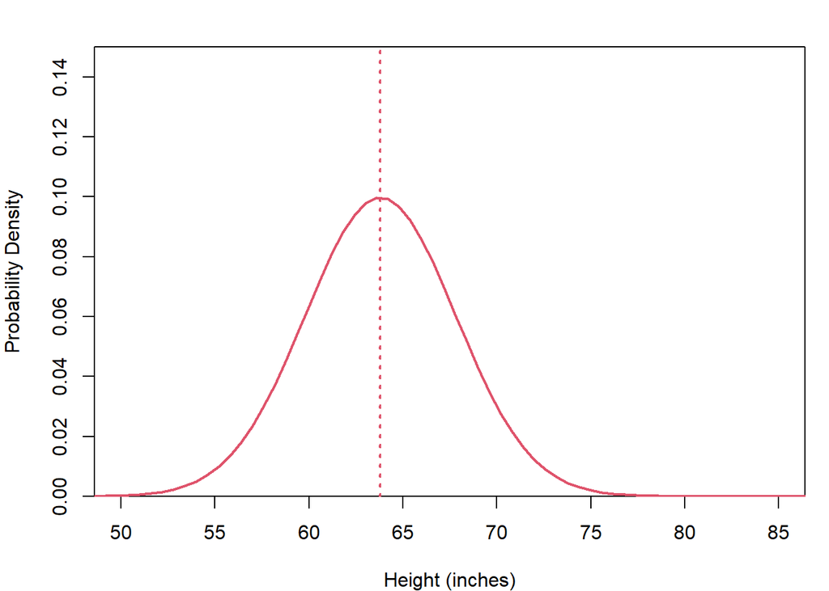

```r
plot (0, xlim = c(50,85), ylim = c(0,.15), xlab = 'Height (inches)', yaxs='i', ylab='Probability Density')
abline (v = 63.8, lwd = 2, col = 2, lty=3)
curve (dnorm (x, 63.8, 4), from = 30, to = 90, lwd=2, col = 2, add = TRUE)
```

Probability distributions are often used to make inferences about the populations they represent.

For example, suppose we want to know the probability of being an adult female and being over 70 inches tall. We can’t possibly find the *true* probability. We would need to go out and tally every woman in the USA. By the time we were done, some would have died and others would have aged into the category.

What we do instead is assume that we can make inferences about a real distribution based on a theoretical distribution. We know that heights tend to be normally distributed. Normal distributions have two parameters:

1. A mean, which determines where the distribution is located along the x axis. The mean is the 50% halfway point of the ‘mass’ of the distribution. If the distribution were an physical object, its mean would be its center of gravity.
2. A standard deviation (or variance, same thing basically) that determines its *spread* along the x axis. Since every distribution has an area under the curve equal to one (they all have the same ‘volume’), the smaller the variance the higher the peak of the density along the y axis.

So this is what scientists will do:

1. Sample a population, and collect measurements.
2. Establish which theoretical distribution best reflects the variation in our data. For continuous data, this will almost always be the normal distribution.
3. Estimate the distribution parameters from the sample. In the case of the normal distribution, this is the mean and standard deviation.
4. Refer to the theoretical distribution to make inferences about the real distribution.

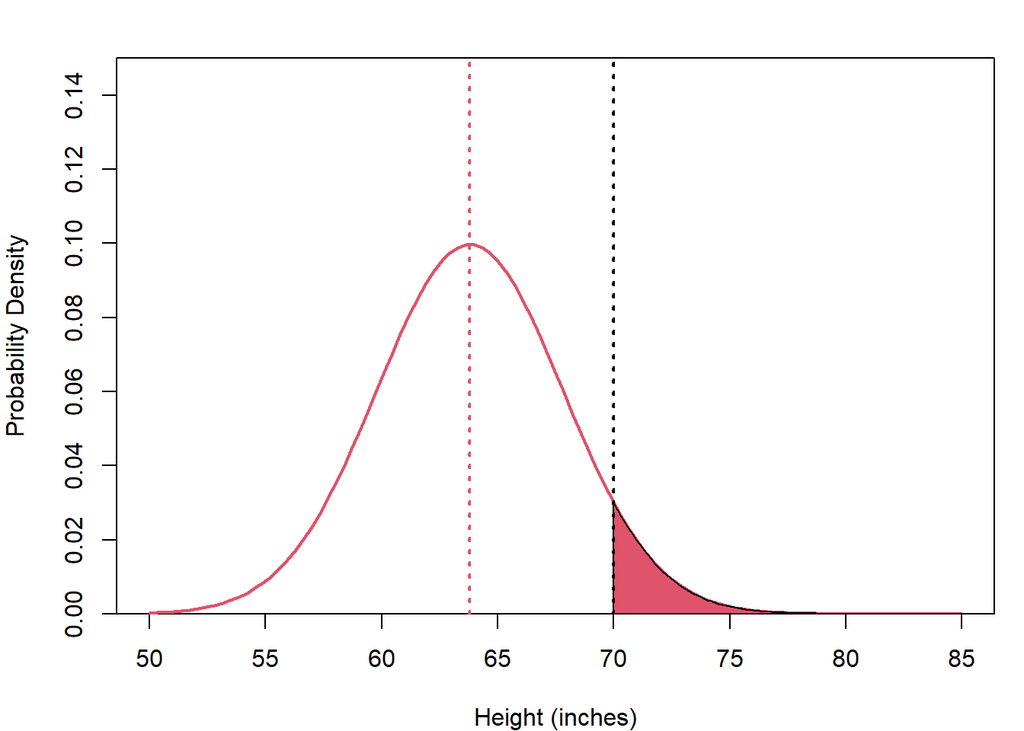

```r
plot (0, xlim = c(50,85), ylim = c(0,.15), xlab = 'Height (inches)', yaxs='i', ylab='Probability Density')
curve(dnorm(x,63.8,4),xlim=c(50,85), lwd = 2, col = 2, add = TRUE)
polygon(c(70,seq(70,86,length.out = 100),86),
        c(0,dnorm(seq(70,86,length.out = 100),63.8,4),0), col='2')
abline (v = 63.8, lwd = 2, col = 2, lty=3)
abline (v = 70, lwd = 2, col = 1, lty=3)
```

```r
## probability that a woman is *less than* 70 inches tall
pnorm (70, 63.8, 4)
```

```
## [1] 0.9394292
```

```r
## probability that a woman is *more than* 70 inches tall
1 - pnorm (70, 63.8, 4)
```

```
## [1] 0.06057076
```

The probability is the expected count of a given phonemenon, when the total number of observations is ‘standardized’ to be one. This helps us compare across many different actual numbers of observations. The probability above suggests the following:

```r
## probability that a woman is *more than* 70 inches tall
(1 - pnorm (70, 63.8, 4)) * 1
```

```
## [1] 0.06057076
```

```r
## Percent of women over 70 inches tall
(1 - pnorm (70, 63.8, 4)) * 100
```

```
## [1] 6.057076
```

```r
## Number out of every 100 women we expect to be over 70 inches tall
(1 - pnorm (70, 63.8, 4)) * 100
```

```
## [1] 6.057076
```

```r
## Number out of every 1000 women we expect to be over 70 inches tall
(1 - pnorm (70, 63.8, 4)) * 1000
```

```
## [1] 60.57076
```

```r
## Number out of every 511 women we expect to be over 70 inches tall
(1 - pnorm (70, 63.8, 4)) * 511
```

```
## [1] 30.95166
```

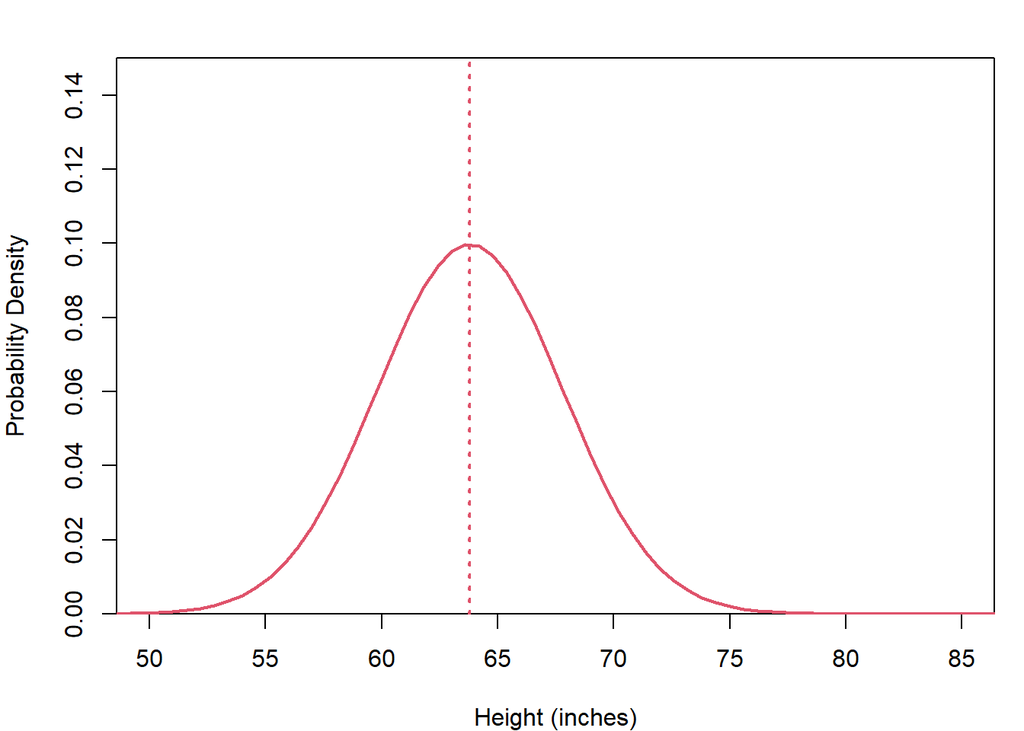

```r
plot (0, xlim = c(50,85), ylim = c(0,.15), xlab = 'Height (inches)', yaxs='i', ylab='Probability Density')
abline (v = 63.8, lwd = 2, col = 2, lty=3)
curve (dnorm (x, 63.8, 4), from = 30, to = 90, lwd=2, col = 2, add = TRUE)
```

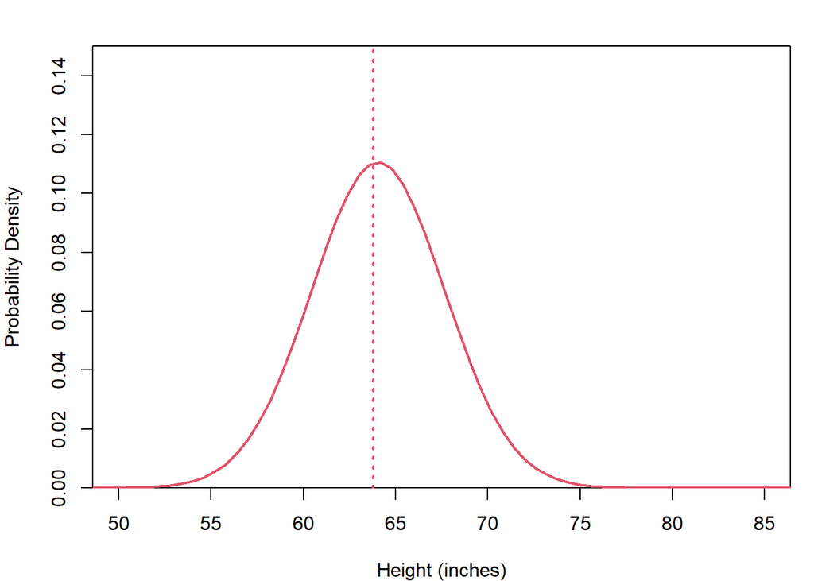

```r
female_heights = rnorm (100, 63.8, 4)
female_height_mean = mean(female_heights)
female_height_sd = sd (female_heights)

plot (0, xlim = c(50,85), ylim = c(0,.15), xlab = 'Height (inches)', yaxs='i', ylab='Probability Density')
abline (v = 63.8, lwd = 2, col = 2, lty=3)
curve (dnorm (x, female_height_mean, female_height_sd), from = 30, to = 90, lwd=2, col = 2, add = TRUE)
```